# Human vs. mouse comparison of results

Vegard Nygaard

07 November, 2018

There are 18 human cell lines treated with DMSO (untreated) and G007LK. And there are one mouse cell line treated with DMSO and G007LK, WNT and G007LK+WNT. The mouse samples are done in triplicates, however here the average will be used. The Human and Mouse data are analysed separately and described in other reports. Here I will try to look for similarities between the species.

I will try this:

- Subset on common genes and do some clustering and see where the mouse samples will fit in.
- Look at fold change correlation in scatter-plot.

```r
human2mouse = read.table("../annotation/mart_export_human2mouse.txt", sep="\t", header=TRUE, stringsAsFactors = FALSE) %>%
    rename(mousesymbol=Mouse.gene.name, humansymbol=Gene.name) %>%
    mutate(mousesymbol = toupper(mousesymbol)) %>%
    dplyr::filter(! (Mouse.homology.type=="ortholog_many2many" & mousesymbol!=humansymbol)) %>%
#   dplyr::filter(Mouse.homology.type %in% c("ortholog_one2one", "ortholog_one2many") )%>%
    dplyr::select(-Transcript.stable.ID) %>%
    distinct()

# human2mouse[human2mouse$humansymbol %in% gsymbols[!notin],]


# problem genes cytokines
# "CXCL1" "CCL12" "CXCL2"

#humansleuthfn = paste0(humandir, "/sleuth_res_treatment_gene_", humandatadate,".txt")
humansleuthfn = paste0(humandir, "/DEGtest_results_", humandatadate, "/G007LK_vs_DMSO_sleuth_results_", humandatadate,".txt")
humansleuthdf = read.table(humansleuthfn , sep="\t", header=TRUE, stringsAsFactors = FALSE) %>%
    rename(foldchange=b) %>%
    mutate(humansymbol = ext_gene)

combodflist = list()
for(i in 1:nrow(treat2baseline))
{

    #mousesleuthdf = read.table( paste0( mousedir, "/sleuth_res_", treat2baseline$comparison[i], "_", mousedatadate,".txt"),
    #                                                       sep="\t", header=TRUE, stringsAsFactors = FALSE) %>%

    mousesleuthdf = read.table( paste0( mousedir, "/mouse_sleuth_res_", treat2baseline$comparison[i], "_", mousedatadate,".txt"),
                                                            sep="\t", header=TRUE, stringsAsFactors = FALSE) %>%
    rename(mousesymbol=ext_gene, foldchange=b) %>%
    dplyr::filter(!duplicated(mousesymbol)) %>%
    left_join(human2mouse[, c("mousesymbol", "humansymbol")])

    combodflist[[i]] = mousesleuthdf[, c("foldchange", "humansymbol", "qval")] %>%
        inner_join(humansleuthdf[, c("foldchange", "humansymbol")], by="humansymbol", suffix=c(".mouse", ".human")) %>%
        dplyr::select(-humansymbol, humansymbol) %>%
        mutate(mousecomparison=treat2baseline$comparison[i])
}

combsleuthddf = do.call("rbind", combodflist)

wntgenes = c("AXIN2", "TCF7")
hippogenes = c("AMOTL2", "CTGF", "CYR61")
notchgenes = c("HEY1", "HEY2")

chiengenes = read.csv("../annotation/chien_genes.csv", stringsAsFactors = FALSE)
cytokinegenes = read.csv("../annotation/cytokine_genes.csv", stringsAsFactors = FALSE)
#focusgenes = c(wntgenes, hippogenes, notchgenes)
```

## Clustering of the mouse samples among the human

```r
# mousechangefn = paste0( mousedir, "/sample_vs_gene_tpm_log2change_mean_" , mousedatadate,".csv")
mousechangefn = paste0( mousedir, "/mouse_sample_vs_gene_tpm_log2change_mean_" , mousedatadate,".csv")
mousechangedf =read.csv( mousechangefn, stringsAsFactors = FALSE) %>%
    rename(mousesymbol=symbol) %>%
    dplyr::filter(!duplicated(mousesymbol)) %>%
    left_join(human2mouse[, c("mousesymbol", "humansymbol")]) %>%
    dplyr::filter(!is.na(humansymbol)) %>%
    dplyr::filter(!duplicated(humansymbol)) %>%
    dplyr::select( -gene_id, -mousesymbol) %>%
    rename_at(vars(-humansymbol), funs(paste0("Mm_", .)))

humanchangefn = paste0( humandir, "/sample_vs_gene_tpm_log2change_", humandatadate,".csv")
humanchangedf =read.csv(humanchangefn , stringsAsFactors = FALSE) %>%
    rename(humansymbol=symbol) %>%
    dplyr::filter(!duplicated(humansymbol)) %>%
    dplyr::filter(!is.na(humansymbol)) %>%
    dplyr::select( -gene_id) %>%
    rename_at(vars(-humansymbol), funs(paste0("Hs_", .)))

changemat = humanchangedf %>%
    inner_join(mousechangedf)
rownames(changemat) = changemat$humansymbol
sumtpmmat = as.matrix(changemat[, grepl("sumTPM", colnames(changemat))])
changemat = as.matrix(changemat[, grepl("change", colnames(changemat))])

# mousesamplevsgenetpmfv = paste0( mousedir, "/sample_vs_gene_tpm_" , mousedatadate,".csv")
mousesamplevsgenetpmfv = paste0( mousedir, "/mouse_sample_vs_gene_tpm_" , mousedatadate,".csv")
mousedf =read.csv(mousesamplevsgenetpmfv , stringsAsFactors = FALSE) %>%
    rename(mousesymbol=symbol) %>%
    dplyr::filter(!duplicated(mousesymbol)) %>%
    left_join(human2mouse[, c("mousesymbol", "humansymbol")]) %>%
    dplyr::filter(!is.na(humansymbol)) %>%
    dplyr::filter(!duplicated(humansymbol)) %>%
    dplyr::select( -gene_id, -mousesymbol) %>%
    rename_at(vars(-humansymbol), funs(paste0("Mm_", .)))

humandf =read.csv( paste0( humandir, "/sample_vs_gene_tpm_", humandatadate,".csv"), stringsAsFactors = FALSE) %>%
    rename(humansymbol=symbol) %>%
    dplyr::filter(!duplicated(humansymbol)) %>%
    dplyr::filter(!is.na(humansymbol)) %>%
    dplyr::select( -gene_id) %>%
    rename_at(vars(-humansymbol), funs(paste0("Hs_", .)))

tpmmat = humandf %>%
    inner_join(mousedf)
rownames(tpmmat) = tpmmat$humansymbol
tpmmat = log2(as.matrix(tpmmat[,-1])+add)
datamat = cbind(tpmmat, changemat)


#sa from file not used here = read.csv("../humananalysis/sa.csv", stringsAsFactors = FALSE)
#mutations =  read.csv("../annotation/pub_mutations.csv", stringsAsFactors = FALSE) %>%
#   mutate(cell_line = make.names(cell_line)) %>%
#   rename(stage=Stage)

cellline_annotation = read_csv("../annotation/cellline_annotation.csv") %>%
    mutate(cell_line = make.names(cell_line))

sa = data.frame(colname=c(colnames(changemat), colnames(tpmmat)),
                                type=c( rep("change", ncol(changemat)), rep("TPM", ncol(tpmmat)) ),
                                species=NA, stringsAsFactors = FALSE)
sa$species[grepl("Mm",sa$colname )] = "mouse"
sa$species[grepl("Hs",sa$colname )] = "human"
sa = sa %>%
    mutate(cell_line=gsub("Hs_|.change|.G007.LK|.DMSO", "", colname))
sa$cell_line[sa$species=="mouse"]="mouse"
sa = sa %>%
#   left_join(mutations) %>%
    left_join(cellline_annotation) %>%
    rename(stage=Stage)

## Take out two samples
if(remove_outliers)
{
    sa = sa %>%
    dplyr::filter(sa$hippo_group_untreated != "outlier")
}
```

Subsets of samples which will be used to cluster by:

```r
samplesubsets = list()
samplesubsets$subsetname = c()
samplesubsets$description = c()
samplesubsets$colnames = list()

subname = "untreated_v1"
samplesubsets$subsetname[[subname]] = subname
samplesubsets$description[[subname]] = "DMSO"
a = sa$type=="TPM"
b = grepl("DMSO", sa$colname)
samplesubsets$colnames[[subname]] = sa$colname[a & b]


subname = "untreated_v2"
samplesubsets$subsetname[[subname]] = subname
samplesubsets$description[[subname]] = "DMSO and also WNT for mouse"
a = sa$type=="TPM"
b = grepl("DMSO", sa$colname)
c = grepl("WNT", sa$colname) & sa$species=="mouse" & !grepl("WNT_G007", sa$colname)
samplesubsets$colnames[[subname]] = sa$colname[a & (b | c)]

subname = "treated_v1"
samplesubsets$subsetname[[subname]] = subname
samplesubsets$description[[subname]] = "G007LK and also WNT_G007LK for mouse"
a = sa$type=="TPM"
b = grepl("G007", sa$colname)
samplesubsets$colnames[[subname]] = sa$colname[a & b]

subname = "treated_v2"
samplesubsets$subsetname[[subname]] = subname
samplesubsets$description[[subname]] = "G007LK and also WNT_G007LK and WNT for mouse"
a = sa$type=="TPM"
b = grepl("G007", sa$colname)
c = grepl("WNT", sa$colname) & sa$species=="mouse" & !grepl("WNT_G007", sa$colname)
samplesubsets$colnames[[subname]] = sa$colname[a & (b | c)]

subname = "change"
samplesubsets$subsetname[[subname]]= subname
samplesubsets$description[[subname]] = "G007LK/DMSO and also the WNT-G007LK/WNT comparisons for mouse"
a = sa$type=="change" & sa$species=="human"
b = sa$colname %in% c("Mm_G007LK_vs_DMSO_change", "Mm_WNT_G007LK_vs_WNT_change")
samplesubsets$colnames[[subname]] = sa$colname[a | b]

kable(as.data.frame(samplesubsets[c("subsetname", "description")]), row.names=FALSE)
```

| subsetname | description |
| --- | --- |
| untreated_v1 | DMSO |
| untreated_v2 | DMSO and also WNT for mouse |
| treated_v1 | G007LK and also WNT_G007LK for mouse |
| treated_v2 | G007LK and also WNT_G007LK and WNT for mouse |
| change | G007LK/DMSO and also the WNT-G007LK/WNT comparisons for mouse |

Subsets of genes which will be used to cluster by:

```r
genesubsets = list()
genesubsets$subsetname = c()
genesubsets$description = c()
genesubsets$symbols = list()
genesubsets$excludeinsampletype = list()

# make sure combsleuthddf is sorted by pval and mousecoparison
combsleuthddf = combsleuthddf %>%
    arrange(qval)
#
# subsetname = "expressed_genes_v1"
# genesubsets$subsetname[[subsetname]] = subsetname
# genesubsets$description[[subsetname]] = "more than 1 TPM in over half the samples"
# a = rowSums(tpmmat > 1) > (ncol(tpmmat)/2)
# genesubsets$symbols[[subsetname]] = rownames(tpmmat)[a]
# genesubsets$excludeinsampletype[[subsetname]] = c("treated", "changed")
#
# subsetname = "expressed_genes_change_v1"
# genesubsets$subsetname[[subsetname]] = subsetname
# genesubsets$description[[subsetname]] = "more than 100 TPM in sum for the treated/untreated sample in over 80% the comparisons"
# a = rowSums(sumtpmmat > 100) > (ncol(sumtpmmat) * 0.8)
# genesubsets$symbols[[subsetname]] = rownames(tpmmat)[a]
# genesubsets$excludeinsampletype[[subsetname]] =c("untreated", "treated")
#
# subsetname = "expressed_genes_change_v2"
# genesubsets$subsetname[[subsetname]] = subsetname
# genesubsets$description[[subsetname]] = "more than 200 TPM in sum for the treated/untreated sample in all the comparisons"
# a = rowSums(sumtpmmat > 200) >= (ncol(sumtpmmat) * 1)
# genesubsets$symbols[[subsetname]] = rownames(tpmmat)[a]
# genesubsets$excludeinsampletype[[subsetname]] =c("untreated", "treated")
#
# subsetname = "expressed_genes__change_v3"
# genesubsets$subsetname[[subsetname]] = subsetname
# genesubsets$description[[subsetname]] = "more than 700 TPM in sum for the treated/untreated sample in all the comparisons"
# a = rowSums(sumtpmmat > 700) >= (ncol(sumtpmmat) * 1)
# genesubsets$symbols[[subsetname]] = rownames(tpmmat)[a]
# genesubsets$excludeinsampletype[[subsetname]] =c("untreated", "treated")

subsetname = "top100human"
genesubsets$subsetname[[subsetname]] = subsetname
genesubsets$description[[subsetname]] = "in the top 100 human G007LK vs DMSO DEGs"
a = rownames(tpmmat) %in% humansleuthdf$humansymbol[1:100]
genesubsets$symbols[[subsetname]] = rownames(tpmmat)[a]

subsetname = "top100mouse_v1"
genesubsets$subsetname[[subsetname]] = subsetname
genesubsets$description[[subsetname]] = "in the top 100 mouse G007LK vs DMSO DEGs "
a = rownames(tpmmat) %in% combsleuthddf$humansymbol[combsleuthddf$mousecomparison=="G007LK_vs_DMSO"][1:100]
genesubsets$symbols[[subsetname]] = rownames(tpmmat)[a]

subsetname = "top100mouse_v2"
genesubsets$subsetname[[subsetname]] = subsetname
genesubsets$description[[subsetname]] = "in the top 100 mouse WNT_G007LK vs WNT DEGs"
a = rownames(tpmmat) %in% combsleuthddf$humansymbol[combsleuthddf$mousecomparison=="WNT_G007LK_vs_WNT"][1:100]
genesubsets$symbols[[subsetname]] = rownames(tpmmat)[a]

subsetname = "WNT"
gsymbols = c(wntgenes)
genesubsets$subsetname[[subsetname]] = subsetname
genesubsets$description[[subsetname]] = paste(gsymbols, collapse=",")
a = rownames(tpmmat) %in% gsymbols
genesubsets$symbols[[subsetname]] = rownames(tpmmat)[a]

subsetname = "HIPPO"
gsymbols = c(hippogenes)
genesubsets$subsetname[[subsetname]] = subsetname
genesubsets$description[[subsetname]] = paste(gsymbols, collapse=",")
a = rownames(tpmmat) %in% gsymbols
genesubsets$symbols[[subsetname]] = rownames(tpmmat)[a]


subsetname = "WNT_HIPPO"
gsymbols = c(wntgenes, hippogenes)
genesubsets$subsetname[[subsetname]] = subsetname
genesubsets$description[[subsetname]] = paste(gsymbols, collapse=",")
a = rownames(tpmmat) %in% gsymbols
genesubsets$symbols[[subsetname]] = rownames(tpmmat)[a]


subsetname = "WNT_HIPPO_NOTCH"
gsymbols = c(wntgenes, hippogenes, notchgenes)
genesubsets$subsetname[[subsetname]] = subsetname
genesubsets$description[[subsetname]] = paste(gsymbols, collapse=",")
a = rownames(tpmmat) %in% gsymbols
genesubsets$symbols[[subsetname]] = rownames(tpmmat)[a]

subsetname = "Chien_genes"
gsymbols = chiengenes$symbol
genesubsets$subsetname[[subsetname]] = subsetname
genesubsets$description[[subsetname]] = paste("29 genes described by Chien et al.")
a = rownames(tpmmat) %in% gsymbols
genesubsets$symbols[[subsetname]] = rownames(tpmmat)[a]

subsetname = "Cytokine_genes"
gsymbols = cytokinegenes$symbol
genesubsets$subsetname[[subsetname]] = subsetname
genesubsets$description[[subsetname]] = paste("32 genes described as cytokins.")
a = rownames(tpmmat) %in% gsymbols
genesubsets$symbols[[subsetname]] = rownames(tpmmat)[a]

subsetname = "MITF_WNT5A_DKK1_DKK3"
gsymbols = c("MITF", "WNT5A", "DKK1", "DKK3")
genesubsets$subsetname[[subsetname]] = subsetname
genesubsets$description[[subsetname]] = paste(gsymbols, collapse=",")
genesubsets$symbols[[subsetname]] = gsymbols

subsetname = "MITF_and_HIPPO"
gsymbols = c("MITF", hippogenes)
genesubsets$subsetname[[subsetname]] = subsetname
genesubsets$description[[subsetname]] = "MITF in comparison with the HIPPO genes"
genesubsets$symbols[[subsetname]] = gsymbols


subsetname = "MITF_and_HIPPO_and_more"
gsymbols = c("MITF", hippogenes, "WNT5A", "DKK1", "DKK3")
genesubsets$subsetname[[subsetname]] = subsetname
genesubsets$description[[subsetname]] = "MITF and in comparison with the HIPPO genes and a few more"
genesubsets$symbols[[subsetname]] = gsymbols


# AMOTL2, CTGF og CYR61 vs MITF


kable(as.data.frame(genesubsets[c("subsetname", "description")]), row.names=FALSE)
```

| subsetname | description |
| --- | --- |
| top100human | in the top 100 human G007LK vs DMSO DEGs |
| top100mouse_v1 | in the top 100 mouse G007LK vs DMSO DEGs |
| top100mouse_v2 | in the top 100 mouse WNT_G007LK vs WNT DEGs |
| WNT | AXIN2,TCF7 |
| HIPPO | AMOTL2,CTGF,CYR61 |
| WNT_HIPPO | AXIN2,TCF7,AMOTL2,CTGF,CYR61 |
| WNT_HIPPO_NOTCH | AXIN2,TCF7,AMOTL2,CTGF,CYR61,HEY1,HEY2 |
| Chien_genes | 29 genes described by Chien et al. |
| Cytokine_genes | 32 genes described as cytokins. |
| MITF_WNT5A_DKK1_DKK3 | MITF,WNT5A,DKK1,DKK3 |
| MITF_and_HIPPO | MITF in comparison with the HIPPO genes |
| MITF_and_HIPPO_and_more | MITF and in comparison with the HIPPO genes and a few more |

5 subsets of samples and 12 subsets of genes will be a total of 60 combinations. But there are more combinations added later since the gene filter based on sum of TMP across many samples dependes on the sample selection and is calculated when needed.  
Only a few of the plots will be part of the article draft.

```r
paperplotsdf = read_csv("samplesetname,genesetname,articlename,pdf,csv,description
untreated_v1,expressed_genes_TPM_v1,fig_suppl13b,1,0,
untreated_v1,expressed_genes_TPM_v2,fig_suppl13c,1,0,
untreated_v1,Chien_genes,fig_suppl13d,1,0,
change,WNT_HIPPO,fig_4d,0,1,
change,expressed_genes_change_v1,fig_suppl17b,1,0,
change,expressed_genes_change_v2,fig_suppl17c,1,0,
change,top100mouse_v1,fig_suppl18a,1,0,
change,top100human,fig_suppl18b,1,0,
untreated_v1,WNT,fig_suppl13a,1,0,
untreated_v1,HIPPO,fig_4a,1,0,
untreated_v2,Cytokine_genes,fig_suppl19b,1,0,
change,Cytokine_genes,fig_suppl19c,1,0,
untreated_v1,MITF_and_HIPPO_and_more,fig_suppl13f,1,0,
change,MITF_and_HIPPO_and_more,fig_suppl17e,1,0,
untreated_v1,MITF_and_HIPPO,fig_suppl13e,1,0,
change,MITF_and_HIPPO,fig_suppl17d,1,0,
")

kable(paperplotsdf)
```

| samplesetname | genesetname | articlename | pdf | csv | description |
| --- | --- | --- | --- | --- | --- |
| untreated_v1 | expressed_genes_TPM_v1 | fig_suppl13b | 1 | 0 | NA |
| untreated_v1 | expressed_genes_TPM_v2 | fig_suppl13c | 1 | 0 | NA |
| untreated_v1 | Chien_genes | fig_suppl13d | 1 | 0 | NA |
| change | WNT_HIPPO | fig_4d | 0 | 1 | NA |
| change | expressed_genes_change_v1 | fig_suppl17b | 1 | 0 | NA |
| change | expressed_genes_change_v2 | fig_suppl17c | 1 | 0 | NA |
| change | top100mouse_v1 | fig_suppl18a | 1 | 0 | NA |
| change | top100human | fig_suppl18b | 1 | 0 | NA |
| untreated_v1 | WNT | fig_suppl13a | 1 | 0 | NA |
| untreated_v1 | HIPPO | fig_4a | 1 | 0 | NA |
| untreated_v2 | Cytokine_genes | fig_suppl19b | 1 | 0 | NA |
| change | Cytokine_genes | fig_suppl19c | 1 | 0 | NA |
| untreated_v1 | MITF_and_HIPPO_and_more | fig_suppl13f | 1 | 0 | NA |
| change | MITF_and_HIPPO_and_more | fig_suppl17e | 1 | 0 | NA |
| untreated_v1 | MITF_and_HIPPO | fig_suppl13e | 1 | 0 | NA |
| change | MITF_and_HIPPO | fig_suppl17d | 1 | 0 | NA |

```r
#humanmaousepdf = paste0(outputdir, "/human_vs_mouse_hclust_", ds, ".pdf")

#pdf(humanmaousepdf)
plotcount=1
for(isample in 1:length(samplesubsets$subsetname))
{

    sname = samplesubsets$subsetname[isample]
    #print(sname)
    sset = samplesubsets$colnames[[sname]]
    samplesubmat = datamat[, sset]

    thisgenesubsets = genesubsets
    if(sname=="change")
    {
        idx = colnames(changemat) %in% colnames(samplesubmat)
        subsetname = "expressed_genes_change_v1"
        thisgenesubsets$subsetname[[subsetname]] = subsetname
        thisgenesubsets$description[[subsetname]] = "more than 100 TPM in sum for the treated+untreated sample in over 80% the comparisons"
        a = rowSums(sumtpmmat[,idx] > 100) > (ncol(sumtpmmat[,idx]) * 0.8)
        thisgenesubsets$symbols[[subsetname]] = rownames(tpmmat)[a]

        subsetname = "expressed_genes_change_v2"
        thisgenesubsets$subsetname[[subsetname]] = subsetname
        thisgenesubsets$description[[subsetname]] = "more than 200 TPM in sum for the treated+untreated sample in all the comparisons"
        a = rowSums(sumtpmmat[,idx] > 200) >= (ncol(sumtpmmat[,idx]) * 1)
        thisgenesubsets$symbols[[subsetname]] = rownames(tpmmat)[a]

        subsetname = "expressed_genes_change_v3"
        thisgenesubsets$subsetname[[subsetname]] = subsetname
        thisgenesubsets$description[[subsetname]] = "more than 700 TPM in sum for the treated+untreated sample in all the comparisons"
        a = rowSums(sumtpmmat[,idx] > 700) >= (ncol(sumtpmmat[,idx]) * 1)
        thisgenesubsets$symbols[[subsetname]] = rownames(tpmmat)[a]

    }else{

        idx = colnames(tpmmat) %in% colnames(samplesubmat)
        subsetname = "expressed_genes_TPM_v1"
        mintpm=1
        thisgenesubsets$subsetname[[subsetname]] = subsetname
        thisgenesubsets$description[[subsetname]] = paste0("more than ", mintpm," TPM in over half the samples")
        a = rowSums(tpmmat[,idx] > mintpm) > (ncol(tpmmat[,idx])/2)
        thisgenesubsets$symbols[[subsetname]] = rownames(tpmmat)[a]

        mintpm=250
        subsetname = "expressed_genes_TPM_v2"
        thisgenesubsets$subsetname[[subsetname]] = subsetname
        thisgenesubsets$description[[subsetname]] = paste0("more than ", mintpm," TPM in over half the samples")
        a = rowSums(tpmmat[,idx] > log2(mintpm)) > (ncol(tpmmat[,idx])/2)
        thisgenesubsets$symbols[[subsetname]] = rownames(tpmmat)[a]

        mintpm=750
        subsetname = "expressed_genes_TPM_v3"
        thisgenesubsets$subsetname[[subsetname]] = subsetname
        thisgenesubsets$description[[subsetname]] = paste0("more than ", mintpm," TPM in over half the samples")
        a = rowSums(tpmmat[,idx] > log2(mintpm)) > (ncol(tpmmat[,idx])/2)
        thisgenesubsets$symbols[[subsetname]] = rownames(tpmmat)[a]
    }



    for(igene in 1:length(thisgenesubsets$subsetname))
    {

        gname = thisgenesubsets$subsetname[igene]
        #print(gname)
        gset = thisgenesubsets$symbols[[gname]]
        submat = samplesubmat[gset,]
        submat = submat[apply(submat, MARGIN=1, FUN=var)!=0,] # take out zero variance rows (i.e no expression)
        colnames(submat) = gsub(".change", "", colnames(submat))
        subsa = sa[match(sset, sa$colname),]

        if(grepl("change", sname))
        {

            # cpalette =  colorRampPalette(c( "blue", "yellow", "red"),
            #                                            bias=1,
            #                                            space="rgb")(n = 50)
            # cpalette = c(cpalette[1:15], cpalette[seq.int(16, 35, 3)], cpalette[36:50])

            breaks=0
            cpalette="-RdYlBu2:100" # same colors as for TPM values
            zscorescaling="none"
            valuedescription = "log2 of G007LK/DMSO TPM"
        }else{
            #cpalette =  colorRampPalette(c("green", "black", "red"),
            #                                            bias=1,
            #                                            space="rgb")(n = 50)
            cpalette="-RdYlBu2:100"
            breaks=NA
            zscorescaling="row"
            valuedescription = "log2 of TPM"
        }

        if(debug)
        {
            if(nrow(submat)>1000)
                submat = submat[sample(1:nrow(submat), 1000),]
        }
        cellheight = 1/nrow(submat)
        pdfheight=7 # default one page
        plotlegend=FALSE
        if(nrow(submat)<=maxgenesinheatmap)
        {
            if(nrow(submat) <= 20)
            {
                    cellheight=10
            }else{
                cellheight=3
            }

            #if(nrow(submat) * cellheight > 250)
            #   cellheight = 250/nrow(submat)

            plotlegend=TRUE
            pdfheight=3.5 +  (nrow(submat) * cellheight)/72 # 72 pixels per inch
            if(pdfheight<7)pdfheight=7
            #print(paste0("pdfheight ", pdfheight))
        }

        undertext = paste0( "samples: ", samplesubsets$description[isample], "\n",
                                             "genes: ", thisgenesubsets$description[igene],  "\n",
                                                "value: ", valuedescription,  "\n",
                                                "zscorecolors: ", zscorescaling)
        plotnumber = sprintf("%02d", plotcount)
        plotname = paste0("hclust",plotcount, "_", sname, "_",gname )

        pdffn = paste0( hclustdir, "/hclust_", plotname, ".pdf")
        pdf( pdffn, height=pdfheight)
        aheatmap(submat,  Colv=T, Rowv=T,
                 na.color="black",
                 color = cpalette,
                 breaks=breaks,
                 scale=zscorescaling,
                 annCol = subsa[,c("species", "stage", "hippo_group_untreated"), drop=FALSE],
                 main=paste0(plotcount, "_", sname, ", ", gname, ", genes=", nrow(submat)),
                 border_color=NA,
                 cellheight=cellheight,
                 cexCol=0.75,
                 treeheight = 30,
                 legend = TRUE,
                 sub=undertext)
        kast=dev.off()
        csvfn = paste0(hclustdir, "/matrix_", plotname, ".csv")
        if(nrow(submat)<=maxgenesincsv)
            write.csv(submat, file=csvfn, row.names=TRUE)
        plotcount = plotcount +1

        a = paperplotsdf$samplesetname==sname & paperplotsdf$genesetname==gname
        if(sum(a)==1)
        {
            #if(paperplotsdf$pdf[a])
            if(TRUE)
            {
                articlefn = paste0(articleplotsdir, "/", paperplotsdf$articlename[a], ".pdf")
                file.copy(pdffn, articlefn, overwrite=TRUE)
            }
            #if(paperplotsdf$csv[a])
            if(TRUE & nrow(submat)<=maxgenesincsv) # dont provide matrix when heatmap is not plotted
            {
                articlefn = paste0(articleplotsdir, "/", paperplotsdf$articlename[a], ".csv")
                file.copy(csvfn, articlefn, overwrite=TRUE)
            }
        }
    }
}
# kast=dev.off()
```

All combinations are plotted as hierarchiacal clusters to files in folder **output_human_vs_mouse_2018-11-07/human_vs_mouse_hclust_2018-11-07**. The input matrix for each plot is also generated.

## Extra

```r
    gname = "MITF_and_HIPPO_and_more"
    sname = "change"
    addmat = changemat[genesubsets$symbols[[gname]],samplesubsets$colnames[[sname]] ]
    addmat = addmat[ , order(addmat["MITF",])]

    cpalette="-RdYlBu2:100"
    breaks=NA
    cellheight=10
    #zscorescaling="row"
    scoretype = c(log2change="none", zscoreoflog2change="row")
    hippolowhighplotfn =  paste0(articleplotsdir , "/fig_suppl17e.pdf")
    pdf( hippolowhighplotfn, height=pdfheight)
    for(st in c(2))
    {
        aheatmap(addmat,  Colv=NA, Rowv=NA,
                 na.color="black",
                 color = cpalette,
                 breaks=breaks,
                 scale=scoretype[st],
                 annCol = sa[match(colnames(addmat), sa$colname),c("species", "stage", "hippo_group_untreated")],
                 main=paste0(gname, " un-clustered \nsorted by MITF change"),
                 border_color=NA,
                 cellheight=cellheight,
                 cexCol=0.75,
                 treeheight = 30,
                 legend = TRUE,
                 sub=paste0( names(scoretype)[st])
                    )

    }
    kast=dev.off()
```

## Foldchange correlation, Human vs. Mouse

Both the human samples and the mouse samples are analyzed in sleuth for DEGs. For the human cell lines, the treatment vs baseline is always GL007 vs DMSO, while for the mouse there are 4 alternative combinations:

```r
    kable(treat2baseline)
```

| treatment | baseline | comparison |
| --- | --- | --- |
| G007LK | DMSO | G007LK_vs_DMSO |
| WNT | DMSO | WNT_vs_DMSO |
| WNT_G007LK | DMSO | WNT_G007LK_vs_DMSO |
| WNT_G007LK | WNT | WNT_G007LK_vs_WNT |

I will make direct scatter-plots between the fold-change found in human and each of the 4 mouse tests.

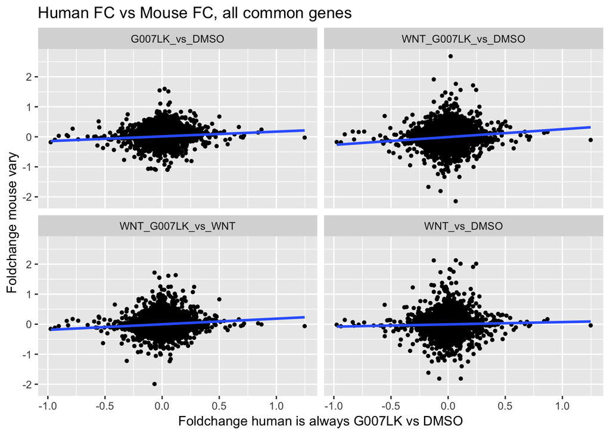

```r
ggplot(combsleuthddf, aes(x=foldchange.human, y=foldchange.mouse )) +
    geom_point(size=1) +
    geom_smooth(method="lm", se=FALSE) +
    ggtitle("Human FC vs Mouse FC, all common genes") +
    xlab("Foldchange human is always G007LK vs DMSO") +
    ylab("Foldchange mouse vary") +
    facet_wrap(~mousecomparison)
```

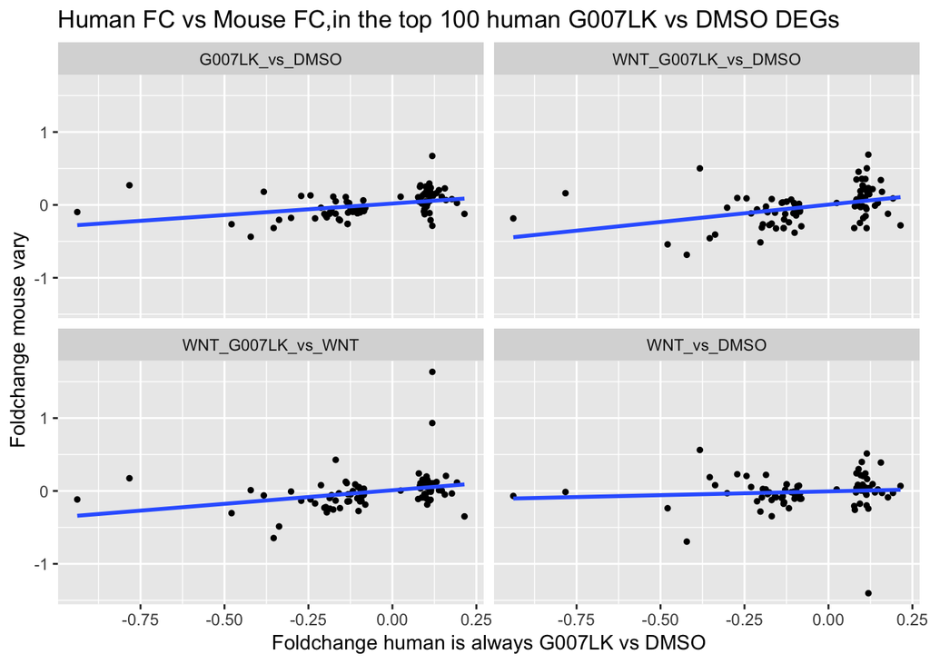

```r
# topn = 100

sname = "top100human"
combsleuthddf %>%
    dplyr::filter(humansymbol %in% genesubsets$symbols[[sname]]) %>%
    ggplot(aes(x=foldchange.human, y=foldchange.mouse )) +
    geom_point(size=1) +
    geom_smooth(method="lm", se=FALSE) +
    ggtitle( paste0("Human FC vs Mouse FC,", genesubsets$description[[sname]])) +
    xlab("Foldchange human is always G007LK vs DMSO") +
    ylab("Foldchange mouse vary") +
    facet_wrap(~mousecomparison)
```

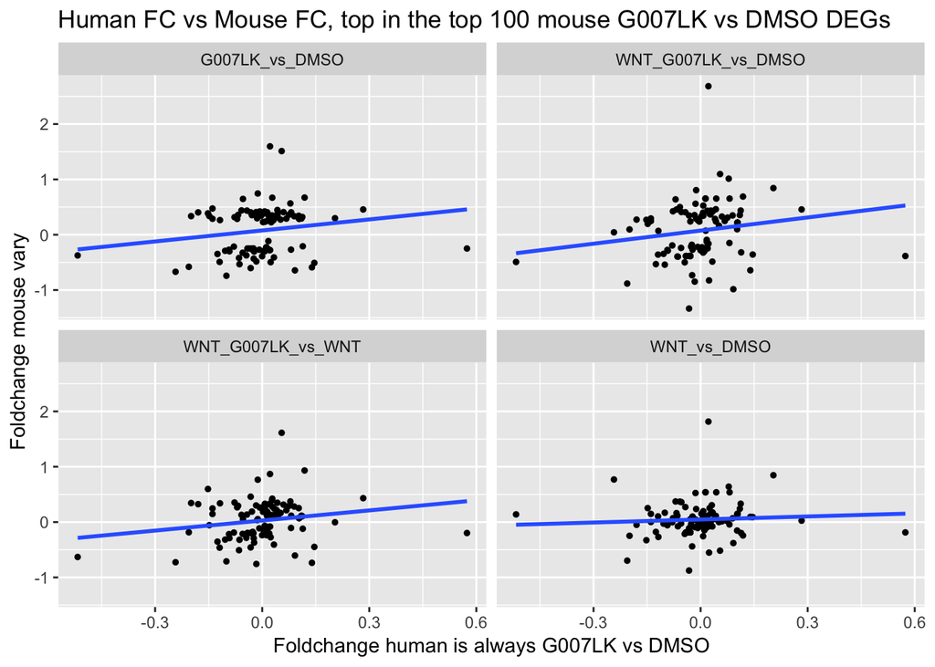

```r
sname = "top100mouse_v1"
combsleuthddf %>%
    dplyr::filter(humansymbol %in% genesubsets$symbols[[sname]]) %>%
    ggplot(aes(x=foldchange.human, y=foldchange.mouse )) +
    geom_point(size=1) +
    geom_smooth(method="lm", se=FALSE) +
    ggtitle( paste0("Human FC vs Mouse FC, top ", genesubsets$description[[sname]])) +
    xlab("Foldchange human is always G007LK vs DMSO") +
    ylab("Foldchange mouse vary") +
    facet_wrap(~mousecomparison)
```

Using a small subset of mostly changed genes in one species does not improve the correlation that much.

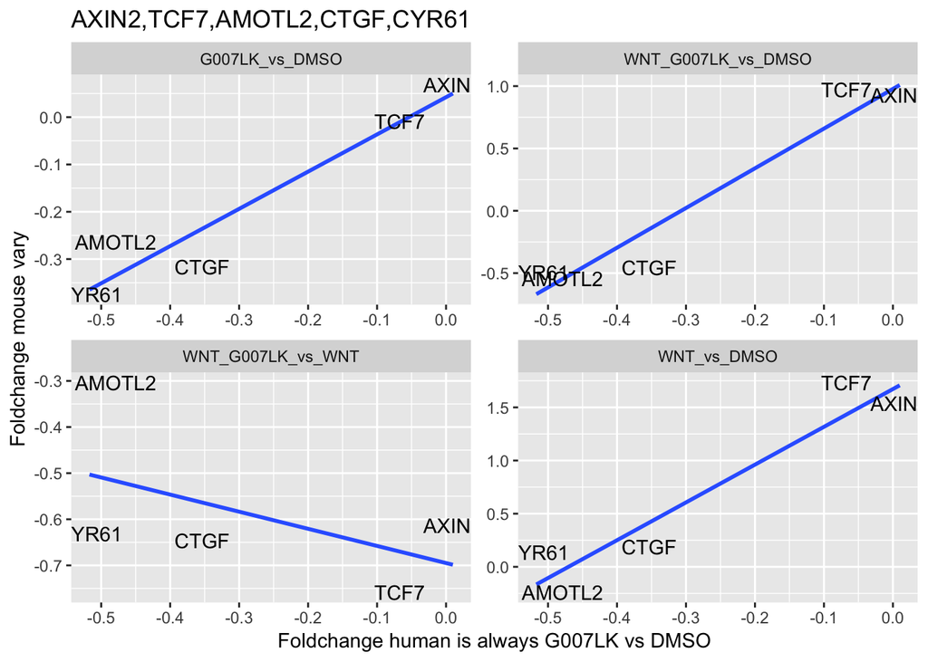

```r
sname = "WNT_HIPPO"
combsleuthddf %>%
    dplyr::filter(humansymbol %in% genesubsets$symbols[[sname]]) %>%
    ggplot(aes(x=foldchange.human, y=foldchange.mouse, label=humansymbol)) +
    geom_smooth(method="lm", se=FALSE) +
    #geom_point(size=3) +
    geom_text() +
    ggtitle( genesubsets$description[[sname]]) +
    xlab("Foldchange human is always G007LK vs DMSO") +
    ylab("Foldchange mouse vary") +
    facet_wrap(~mousecomparison, scales="free")
```